# tutorial

## Analyzing Cyber Security Job Salaries: Insights and Trends in the Industry

By Etmy Barbosa

### Introduction

#### Motivation

Understanding the job market and salary trends in cybersecurity is crucial for both job seekers and employers. The ever-growing demand for experienced professionals to guard against cyber threats highlights the importance of having a comprehensive overview of the compensation landscape. This relevance extends to the field of data science, where analyzing and predicting salary trends can inform better decision-making and strategic planning.

In this tutorial, we will perform an in-depth analysis of cybersecurity job salaries. We will guide you through the entire data science pipeline, from data collection and processing to exploratory data analysis, hypothesis testing, machine learning, and deriving actionable insights. Using a dataset of cybersecurity job salaries, we will examine key parameters that determine salary levels, such as job title, years of experience, and location.

By the end of this tutorial, you will have the capability to draw meaningful inferences about salary trends in the cybersecurity sector. This knowledge will aid in making informed decisions regarding career paths and competitive compensation packages. Whether you are a job seeker negotiating a salary or an employer looking to attract top talent, this analysis will provide valuable insights to support your decisions.

#### Additional Resources

- [Kaggle: Datasets](https://www.kaggle.com/datasets) - A wide variety of datasets for practice and analysis.
- [Pandas Documentation](https://pandas.pydata.org/pandas-docs/stable/) - Official documentation for the Pandas library.
- [Real Python: Cleaning Data](https://realpython.com/python-data-cleaning-numpy-pandas/) - A tutorial on data cleaning using Python.
- [Seaborn Documentation](https://seaborn.pydata.org/) - Official documentation for the Seaborn visualization library.
- [DataCamp: Exploratory Data Analysis in Python](https://www.datacamp.com/courses/exploratory-data-analysis-in-python) - An online course on EDA.
- [Matplotlib Documentation](https://matplotlib.org/stable/contents.html) - Official documentation for the Matplotlib library.
- [Statistical Hypothesis Testing in Python](https://machinelearningmastery.com/statistical-hypothesis-tests-in-python-cheat-sheet/) - A cheat sheet for hypothesis testing in Python.
- [Wikipedia: Hypothesis Testing](https://en.wikipedia.org/wiki/Hypothesis_testing) - An overview of hypothesis testing concepts.
- [Scikit-Learn Documentation](https://scikit-learn.org/stable/documentation.html) - Official documentation for the Scikit-Learn library.
- [Coursera: Machine Learning by Andrew Ng](https://www.coursera.org/learn/machine-learning) - A popular course on machine learning.
- [KDnuggets: Data Science and Machine Learning](https://www.kdnuggets.com/) - A website with articles and tutorials on data science and machine learning.
- [Google Scholar](https://scholar.google.com/) - A search engine for scholarly literature.

### Data Collection

The first step in any data science project is collecting the data that will be analyzed. For this tutorial, we are using a dataset containing information about cyber security job salaries. This dataset includes various attributes such as job titles, years of experience, geographical locations, and salary figures. The dataset is sourced from kaggle.com and is assumed to be representative of the industry.

To start with, we need to load the dataset into our working environment and take a preliminary look at its structure and contents. This will help us understand what kind of data we are dealing with and what preprocessing steps might be necessary before analysis.

We begin by importing the dataset using Pandas and inspecting the first few rows to understand its structure. Next, we handle missing values and perform data cleaning to ensure our dataset is accurate and reliable for analysis.

```python
# imports
import requests
from bs4 import BeautifulSoup as bs
import pandas as pd
import datetime as dt
from datetime import datetime
import numpy as np
import matplotlib.pyplot as plt
import seaborn as sns
import plotly.express as px
import plotly.io as pio
import scipy.stats as stats
from sklearn.linear_model import LinearRegression
from sklearn.metrics import mean_squared_error, r2_score
from sklearn.linear_model import Ridge

%matplotlib inline
```

```python
# Load the dataset
data = pd.read_csv('/Users/etmybarbosa/Desktop/tutorial/salaries_cyber.csv')

#Display the first few rows of the dataset
print(data.head())
```

```
   work_year experience_level employment_type               job_title  salary  \
0       2022               EN              FT   Cyber Program Manager   63000
1       2022               MI              FT        Security Analyst   95000
2       2022               MI              FT        Security Analyst   70000
3       2022               MI              FT     IT Security Analyst  250000
4       2022               EN              CT  Cyber Security Analyst  120000

  salary_currency  salary_in_usd employee_residence  remote_ratio  \
0             USD          63000                 US            50
1             USD          95000                 US             0
2             USD          70000                 US             0
3             BRL          48853                 BR            50
4             USD         120000                 BW           100

  company_location company_size
0               US            S
1               US            M
2               US            M
3               BR            L
4               BW            S
```

```python
#Display basic information about the dataset
print(data.info())
```

```
<class 'pandas.core.frame.DataFrame'>
RangeIndex: 1247 entries, 0 to 1246
Data columns (total 11 columns):
 #   Column              Non-Null Count  Dtype
---  ------              --------------  -----
 0   work_year           1247 non-null   int64
 1   experience_level    1247 non-null   object
 2   employment_type     1247 non-null   object
 3   job_title           1247 non-null   object
 4   salary              1247 non-null   int64
 5   salary_currency     1247 non-null   object
 6   salary_in_usd       1247 non-null   int64
 7   employee_residence  1247 non-null   object
 8   remote_ratio        1247 non-null   int64
 9   company_location    1247 non-null   object
 10  company_size        1247 non-null   object
dtypes: int64(4), object(7)
memory usage: 107.3+ KB
None
```

```python
# Check for missing values
print(data.isnull().sum())
```

```
work_year             0
experience_level      0
employment_type       0
job_title             0
salary                0
salary_currency       0
salary_in_usd         0
employee_residence    0
remote_ratio          0
company_location      0
company_size          0
dtype: int64
```

### Data Processing

After collecting the data, the next step is data processing. This involves cleaning the data, handling missing values, and transforming it into a format suitable for analysis.

in this section we will:

1. Identify and handle any missing values in the dataset. Depending on the context, we might drop rows with missing values or fill them with appropriate values (e.g., mean, median, mode).
2. ensure that all columns have appropriate data types. For example, numerical columns should be in numeric format, and categorical columns should be in string format.
3. If necessary, we will create new features that might be useful for the analysis.

```python
# Handle missing values (e.g., drop rows with missing values)
data_cleaned = data.dropna()

# Ensure all columns are of appropriate data types
print(data_cleaned.dtypes)
```

```
work_year              int64
experience_level      object
employment_type       object
job_title             object
salary                 int64
salary_currency       object
salary_in_usd          int64
employee_residence    object
remote_ratio           int64
company_location      object
company_size          object
dtype: object
```

```python
data_cleaned['experience_level'] = data_cleaned['experience_level'].replace({'EN': 'Entry-Level', 'MI': 'Mid-Level', 'EX': 'Executive Level', 'SE': 'Senior'})
data_cleaned['employment_type'] = data_cleaned['employment_type'].replace({'PT': 'Part-Time', 'FT': 'Full-Time', 'CT': 'Contract', 'FL': 'Freelance'})
```

```python
unique_company_locations = data_cleaned['company_location'].unique()
print("Unique Company Locations:")
print(unique_company_locations)
```

```
Unique Company Locations:
['US' 'BR' 'BW' 'GB' 'SG' 'NL' 'IN' 'DE' 'AE' 'CA' 'CH' 'DK' 'CL' 'ES'
 'AU' 'FR' 'IT' 'JP' 'GR' 'AZ' 'RO' 'DZ' 'AQ' 'AX' 'SI' 'HR' 'SE' 'HU'
 'ET' 'MX' 'IL' 'IE' 'PK' 'NO' 'PL' 'PT' 'RU' 'CZ' 'ID' 'EE' 'KE' 'RS'
 'AR' 'NZ' 'BE' 'ZA' 'AT' 'UM' 'LU' 'EG' 'TW' 'VN' 'SA' 'AF' 'TR']
```

```python
#create a dictionary to map country abbreviations to full names
country_map = {
    'US': 'United States',
    'BR': 'Brazil',
    'BW': 'Botswana',
    'GB': 'United Kingdom',
    'SG': 'Singapore',
    'NL': 'Netherlands',
    'IN': 'India',
    'DE': 'Germany',
    'AE': 'United Arab Emirates',
    'CA': 'Canada',
    'CH': 'Switzerland',
    'DK': 'Denmark',
    'CL': 'Chile',
    'ES': 'Spain',
    'AU': 'Australia',
    'FR': 'France',
    'IT': 'Italy',
    'JP': 'Japan',
    'GR': 'Greece',
    'AZ': 'Azerbaijan',
    'RO': 'Romania',
    'DZ': 'Algeria',
    'AQ': 'Antarctica',
    'AX': 'Åland Islands',
    'SI': 'Slovenia',
    'HR': 'Croatia',
    'SE': 'Sweden',
    'HU': 'Hungary',
    'ET': 'Ethiopia',
    'MX': 'Mexico',
    'IL': 'Israel',
    'IE': 'Ireland',
    'PK': 'Pakistan',
    'NO': 'Norway',
    'PL': 'Poland',
    'PT': 'Portugal',
    'RU': 'Russia',
    'CZ': 'Czech Republic',
    'ID': 'Indonesia',
    'EE': 'Estonia',
    'KE': 'Kenya',
    'RS': 'Serbia',
    'AR': 'Argentina',
    'NZ': 'New Zealand',
    'BE': 'Belgium',
    'ZA': 'South Africa',
    'AT': 'Austria',
    'UM': 'United States Minor Outlying Islands',
    'LU': 'Luxembourg',
    'EG': 'Egypt',
    'TW': 'Taiwan',
    'VN': 'Vietnam',
    'SA': 'Saudi Arabia',
    'AF': 'Afghanistan',
    'TR': 'Turkey',
    'CR': 'Costa Rica'
}


#replace country abbreviations with full country names
data_cleaned['employee_residence'] = data_cleaned['employee_residence'].replace(country_map)
```

```python
data_cleaned['employment_type'] = data_cleaned['employment_type'].replace({
    'PT': 'Part-Time',
    'FT': 'Full-Time',
    'CT': 'Contract',
    'FL': 'Freelance'
})
```

```python
#display the cleaned dataset
print(data_cleaned.head())
```

```
   work_year experience_level employment_type               job_title  salary  \
0       2022      Entry-Level       Full-Time   Cyber Program Manager   63000
1       2022        Mid-Level       Full-Time        Security Analyst   95000
2       2022        Mid-Level       Full-Time        Security Analyst   70000
3       2022        Mid-Level       Full-Time     IT Security Analyst  250000
4       2022      Entry-Level        Contract  Cyber Security Analyst  120000

  salary_currency  salary_in_usd employee_residence  remote_ratio  \
0             USD          63000      United States            50
1             USD          95000      United States             0
2             USD          70000      United States             0
3             BRL          48853             Brazil            50
4             USD         120000           Botswana           100

  company_location company_size
0               US            S
1               US            M
2               US            M
3               BR            L
4               BW            S
```

```python
# Not Neccessary
data_cleaned.to_csv('cleaned_salaries_cyber.csv', index=False)
```

### Exploratory Analysis & Data Visualization

With the data cleaned and processed, we can now perform exploratory data analysis (EDA) and create visualizations to understand the main characteristics of the dataset. This step helps uncover patterns, trends, and relationships within the data.

```python
# Summary statistics
print(data_cleaned.describe())
```

```
         work_year        salary  salary_in_usd  remote_ratio
count  1247.000000  1.247000e+03    1247.000000   1247.000000
mean   2021.316760  5.608525e+05  120278.218925     71.491580
std       0.715501  1.415944e+07   70291.394942     39.346851
min    2020.000000  1.740000e+03    2000.000000      0.000000
25%    2021.000000  7.975450e+04   74594.500000     50.000000
50%    2021.000000  1.200000e+05  110000.000000    100.000000
75%    2022.000000  1.600800e+05  150000.000000    100.000000
max    2022.000000  5.000000e+08  910991.000000    100.000000
```

```python
print("Columns in the dataset:", data.columns)
```

```
Columns in the dataset: Index(['work_year', 'experience_level', 'employment_type', 'job_title',
       'salary', 'salary_currency', 'salary_in_usd', 'employee_residence',
       'remote_ratio', 'company_location', 'company_size'],
      dtype='object')
```

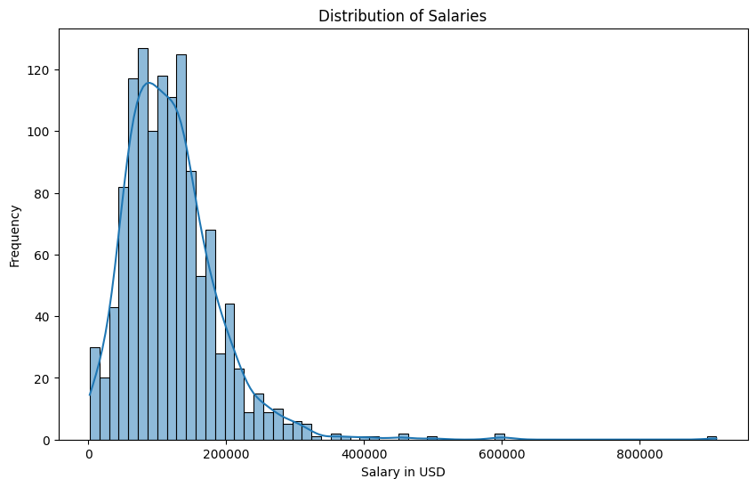

```python
# plot the distribution of salaries
plt.figure(figsize=(10, 6))
sns.histplot(data_encoded['salary_in_usd'], kde=True)
plt.title('Distribution of Salaries')
plt.xlabel('Salary in USD')
plt.ylabel('Frequency')
plt.show()
```

The histogram above shows the distribution of salaries in USD. We use a Kernel Density Estimate (KDE) to smooth the distribution curve and provide a clearer picture of the data's underlying trends. This visualization helps in identifying the range, central tendencies, and variability in salaries across different roles within the cybersecurity sector.

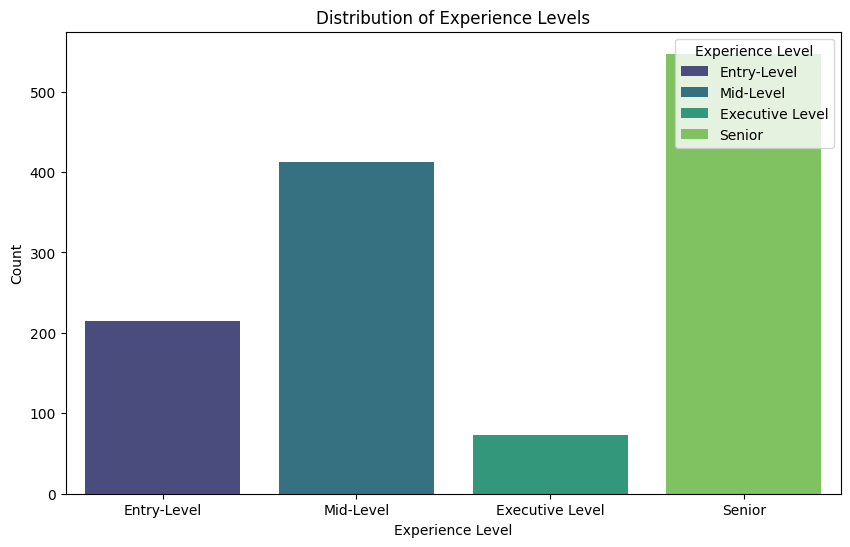

```python
plt.figure(figsize=(10, 6))
sns.countplot(data=data_cleaned, x='experience_level', hue='experience_level', palette='viridis', dodge=False)
plt.title('Distribution of Experience Levels')
plt.xlabel('Experience Level')
plt.ylabel('Count')
plt.legend(title='Experience Level', loc='upper right', labels=data_cleaned['experience_level'].unique())
plt.show()
```

The bar plot above illustrates the distribution of experience levels within the cybersecurity workforce. Each bar represents a different experience level: Entry-Level, Mid-Level, Executive Level, and Senior. The height of each bar indicates the number of individuals at each experience level. This visualization helps in understanding the composition of the workforce by experience level, revealing that Senior-level positions are the most common, followed by Mid-Level, Entry-Level, and Executive Level positions. The distinct colors for each bar enhance clarity and allow for easy comparison across experience levels.

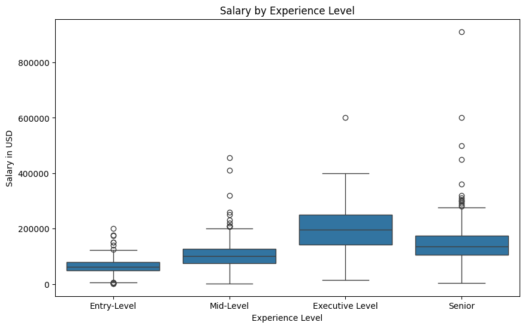

```python
# plot the relationship between experience level and salary
plt.figure(figsize=(10, 6))
sns.boxplot(x='experience_level', y='salary_in_usd', data=data_cleaned)
plt.title('Salary by Experience Level')
plt.xlabel('Experience Level')
plt.ylabel('Salary in USD')
plt.show()
```

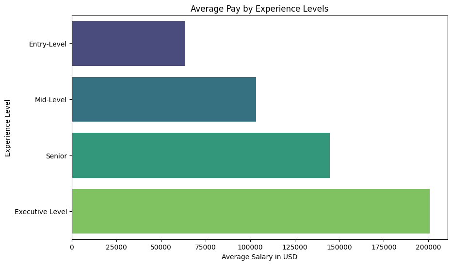

```python
# average pay by experience levels
avg_pay_by_experience = data_cleaned.groupby('experience_level')['salary_in_usd'].mean().sort_values()

# bar plot for Average Pay by Experience Levels
plt.figure(figsize=(10, 6))
sns.barplot(x=avg_pay_by_experience.values, y=avg_pay_by_experience.index, hue=avg_pay_by_experience.index, dodge=False, palette='viridis', legend=False)
plt.title('Average Pay by Experience Levels')
plt.xlabel('Average Salary in USD')
plt.ylabel('Experience Level')
plt.show()
```

The bar plot above illustrates the average pay for different experience levels within the cybersecurity industry. Each bar represents the average salary in USD for a specific experience level: Entry-Level, Mid-Level, Senior, and Executive Level. The length of each bar indicates the average salary for that experience level, providing a clear comparison of compensation across different stages of career progression. This visualization helps in understanding the financial rewards associated with various levels of experience, revealing that higher experience levels generally correspond to higher average salaries, with Executive Level positions commanding the highest pay.

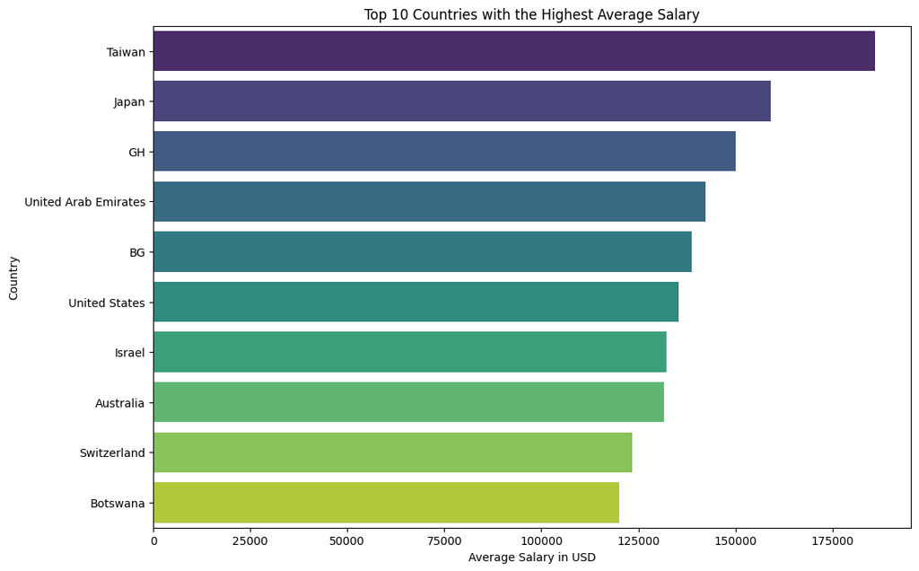

```python
#Calculate the average salary for each country
avg_salary_by_country = data_cleaned.groupby('employee_residence')['salary_in_usd'].mean().sort_values(ascending=False)

#Identify the country with the highest average salory
highest_avg_salary_country = avg_salary_by_country.idxmax()
highest_avg_salary = avg_salary_by_country.max()

#Create a bar plot for the top 10 countries with the highest average salary
plt.figure(figsize=(12, 8))
top_10_countries = avg_salary_by_country.head(10).reset_index()
sns.barplot(x='salary_in_usd', y='employee_residence', data=top_10_countries, hue='employee_residence', dodge=False, palette='viridis')
plt.title('Top 10 Countries with the Highest Average Salary')
plt.xlabel('Average Salary in USD')
plt.ylabel('Country')

plt.show()
```

The bar plot above highlights the top 10 countries with the highest average salaries in the cybersecurity industry. Each bar represents a country, and the length of the bar indicates the average salary in USD for cybersecurity professionals in that country. This visualization provides a clear comparison of average salaries across different countries, revealing significant geographic variations in compensation. The plot shows that Taiwan offers the highest average salary, followed by Japan, Ghana, and other countries. This information is valuable for understanding global salary trends and identifying the countries that offer the most lucrative opportunities for cybersecurity professionals.

```python
# print the contry with the highest average salary
print(f"The country with the highest average salary is {highest_avg_salary_country} with an average salary of {highest_avg_salary:.2f} USD.")
```

```
The country with the highest average salary is Taiwan with an average salary of 185906.00 USD.
```

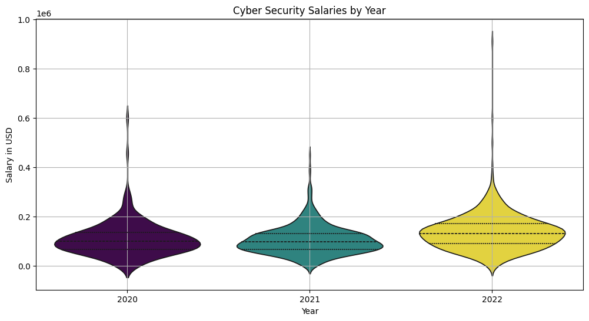

```python
# Create a violin plot for the salary distribution by year
plt.figure(figsize=(12, 6))
sns.violinplot(x='work_year', y='salary_in_usd', data=data_cleaned, inner='quartile', hue='work_year', palette='viridis', density_norm='width', legend=False)
plt.title('Cyber Security Salaries by Year')
plt.xlabel('Year')
plt.ylabel('Salary in USD')
plt.grid(True)

plt.show()
```

The violin plot above depicts the distribution of cybersecurity salaries across different years. Each violin represents a specific year, showing the density of salary values in USD. The width of the violin at any given point indicates the number of observations at that salary level. The plot also includes quartile markers, providing insights into the spread, central tendency, and variability of salaries for each year. This visualization helps in understanding how cybersecurity salaries have evolved over time, highlighting trends and patterns in compensation within the industry from 2020 to 2022.

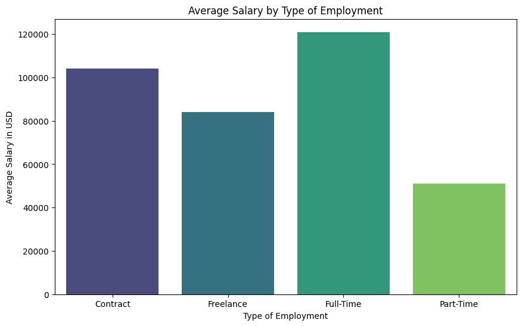

```python
# calculate the average salarry by employment type
avg_salary_by_employment_type = data_cleaned.groupby('employment_type')['salary_in_usd'].mean().reset_index()

# create a bar plot for the average salary by employment type
plt.figure(figsize=(10, 6))
sns.barplot(x='employment_type', y='salary_in_usd', data=avg_salary_by_employment_type, hue='employment_type', dodge=False, palette='viridis', legend=False)
plt.title('Average Salary by Type of Employment')
plt.xlabel('Type of Employment')
plt.ylabel('Average Salary in USD')

plt.show()
```

The bar plot above illustrates the average salary for different types of employment within the cybersecurity industry. Each bar represents a specific employment type: Contract, Freelance, Full-Time, and Part-Time. The height of each bar indicates the average salary in USD for that employment type. This visualization provides a clear comparison of compensation across different employment arrangements, revealing that Full-Time positions generally offer the highest average salaries, followed by Contract, Freelance, and Part-Time positions. This information helps in understanding how employment type impacts salary levels in the cybersecurity sector.

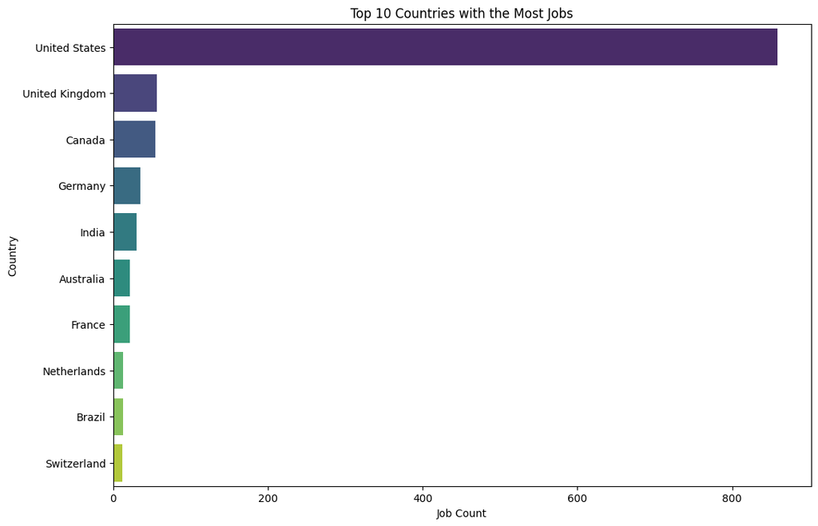

```python
# Calculate the count of jobs by country
jobs_by_country = data_cleaned['employee_residence'].value_counts().head(10).reset_index()
jobs_by_country.columns = ['Country', 'Job Count']

#  Create a bar plot for the top 10 countries with the most jobs
plt.figure(figsize=(12, 8))
sns.barplot(x='Job Count', y='Country', data=jobs_by_country, hue='Country', dodge=False, palette='viridis', legend=False)
plt.title('Top 10 Countries with the Most Jobs')
plt.xlabel('Job Count')
plt.ylabel('Country')
plt.show()
```

The bar plot above presents the top 10 countries with the highest number of cybersecurity jobs. Each bar represents a country, and the length of the bar indicates the job count in that country. This visualization provides a clear comparison of job availability across different countries, highlighting which nations have the most significant number of cybersecurity positions. The plot reveals that the United States leads by a substantial margin, followed by the United Kingdom, Canada, Germany, and other countries. This information is valuable for understanding the global distribution of cybersecurity jobs and identifying key markets for employment opportunities.

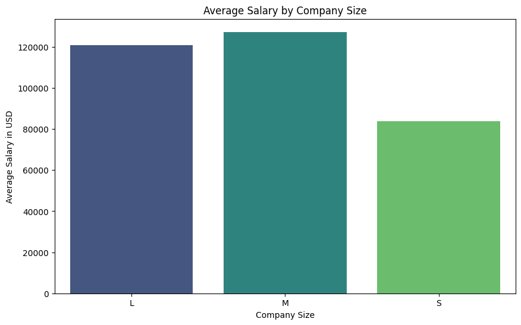

```python
#calculate the average salary by company size
avg_salary_by_company_size = data_cleaned.groupby('company_size')['salary_in_usd'].mean().reset_index()

#reate a bar plot for the average salary by company size
plt.figure(figsize=(10, 6))
sns.barplot(x='company_size', y='salary_in_usd', data=avg_salary_by_company_size, hue='company_size', dodge=False, palette='viridis', legend=False)
plt.title('Average Salary by Company Size')
plt.xlabel('Company Size')
plt.ylabel('Average Salary in USD')
plt.show()
```

The bar plot above illustrates the average salary for different company sizes within the cybersecurity industry. Each bar represents a company size category: Small (S), Medium (M), and Large (L). The height of each bar indicates the average salary in USD for employees working in companies of that size. This visualization provides a clear comparison of compensation across different company sizes, revealing that Medium-sized companies offer the highest average salaries, followed closely by Large companies, with Small companies offering comparatively lower average salaries. This information is valuable for understanding how company size impacts salary levels in the cybersecurity sector.

### Model: Analysis, Hypothesis Testing, & ML

In this section, we performed a series of statistical tests and built predictive models to analyze the cybersecurity job salary data. The aim was to identify significant factors affecting salaries and to build models that can predict salary based on these factors.

##### ANOVA Test

We conducted a one-way ANOVA (Analysis of Variance) test to determine if there are significant differences in salaries across different experience levels.

```python
# One-way ANOVA test to check if there is a significant difference in salaries across experience levels
experience_groups = [data_cleaned[data_cleaned['experience_level'] == level]['salary_in_usd'] for level in data_cleaned['experience_level'].unique()]
anova_result = stats.f_oneway(*experience_groups)

print('ANOVA test for salaries across different experience levels:')
print('F-statistic:', anova_result.statistic)
print('p-value:', anova_result.pvalue)
```

```
ANOVA test for salaries across different experience levels:
F-statistic: 145.93832002864494
p-value: 5.146304330240454e-81
```

The ANOVA test resulted in a very high F-statistic (145.94) and a p-value close to zero (5.15e-81). This indicates that there are significant differences in salaries across different experience levels. Thus, experience level is a key factor influencing salary in the cybersecurity field.

##### Linear Regression Model

We built a Linear Regression model to predict salaries based on various features. The model was trained on the training dataset and evaluated on both training and test datasets.

```python
# Initialize and train the linear regression model
model = LinearRegression()
model.fit(X_train, y_train)

# Make predictions
y_pred_train = model.predict(X_train)
y_pred_test = model.predict(X_test)

# Evaluate the model on the train set
mse_train = mean_squared_error(y_train, y_pred_train)
r2_train = r2_score(y_train, y_pred_train)

print('Train Mean Squared Error:', mse_train)
print('Train R-squared:', r2_train)

# Evaluate the model on the test set
mse_test = mean_squared_error(y_test, y_pred_test)
r2_test = r2_score(y_test, y_pred_test)

print('Test Mean Squared Error:', mse_test)
print('Test R-squared:', r2_test)
```

```
Train Mean Squared Error: 4660619418.357751
Train R-squared: 0.064924181220268
Test Mean Squared Error: 4650949915.659817
Test R-squared: 0.020147709920395274
```

The Linear Regression model showed a Train R-squared of 0.0649 and a Test R-squared of 0.0201, indicating that the model explains only a small portion of the variance in the salary data. The Mean Squared Error (MSE) is quite high for both train and test sets, suggesting that the model's predictions are not very accurate. This implies that the relationship between the features and salary might be more complex than a linear relationship.

##### Ridge Regression Model

We also built a Ridge Regression model to see if adding regularization improves the predictive performance. Ridge Regression helps to mitigate overfitting by adding a penalty to the size of coefficients.

```python
# Initialize and train the Ridge regression model
ridge_model = Ridge(alpha=1.0)
ridge_model.fit(X_train, y_train)

# make predictions
ridge_y_pred_train = ridge_model.predict(X_train)
ridge_y_pred_test = ridge_model.predict(X_test)

# Evaluate the Ridge model on the train set
ridge_mse_train = mean_squared_error(y_train, ridge_y_pred_train)
ridge_r2_train = r2_score(y_train, ridge_y_pred_train)

print('Ridge Train Mean Squared Error:', ridge_mse_train)
print('Ridge Train R-squared:', ridge_r2_train)

# Evaluate the Ridge model on the test set
ridge_mse_test = mean_squared_error(y_test, ridge_y_pred_test)
ridge_r2_test = r2_score(y_test, ridge_y_pred_test)

print('Ridge Test Mean Squared Error:', ridge_mse_test)
print('Ridge Test R-squared:', ridge_r2_test)
```

```
Ridge Train Mean Squared Error: 4660620039.0665045
Ridge Train R-squared: 0.06492405668537393
Ridge Test Mean Squared Error: 4650693382.211755
Ridge Test R-squared: 0.020201755844587832
```

The Ridge Regression model showed similar performance to the Linear Regression model, with Train R-squared of 0.0649 and Test R-squared of 0.0202. The slight improvement in Test R-squared suggests that regularization had a minor positive effect, but overall, the model still explains only a small portion of the variance in the salary data.

##### Comparison of Models

```python
# Print comparison of Linear Regression and Ridge Regression models
print('Linear Regression Model:')
print('Test Mean Squared Error:', mse_test)
print('Test R-squared:', r2_test)

print('Ridge Regression Model:')
print('Test Mean Squared Error:', ridge_mse_test)
print('Test R-squared:', ridge_r2_test)
```

```
Linear Regression Model:
Test Mean Squared Error: 4650949915.659817
Test R-squared: 0.020147709920395274
Ridge Regression Model:
Test Mean Squared Error: 4650693382.211755
Test R-squared: 0.020201755844587832
```

Both models performed similarly, with Ridge Regression showing a slight improvement in Test R-squared and a marginally lower Test MSE. This suggests that while regularization helps slightly, the overall model performance indicates that the linear models may not capture the complexity of the data well. Further exploration with more complex models or additional features might be necessary to improve prediction accuracy.

##### Additional Resources

- [Scikit-Learn: Linear Regression](https://scikit-learn.org/stable/modules/linear_model.html#linear-regression)
- [Scikit-Learn: Ridge Regression](https://scikit-learn.org/stable/modules/linear_model.html#ridge-regression)
- [Towards Data Science: Linear Regression](https://towardsdatascience.com/linear-regression-detailed-view-ea73175f6e86)
- [Towards Data Science: Ridge Regression](https://towardsdatascience.com/ridge-regression-theory-and-python-implementation-1db409e555d4)

### Interpretation: Insight & Policy Decision

#### Additional Resources

- [U.S. Bureau of Labor Statistics: Information Security Analysts](https://www.bls.gov/ooh/computer-and-information-technology/information-security-analysts.htm) - Comprehensive information on job outlook, pay, and work environment for information security analysts.
- [CyberSeek: Career Pathways](https://www.cyberseek.org/pathway.html) - Interactive career pathways tool that provides insights into different cybersecurity roles, required skills, and salary information.
- [National Initiative for Cybersecurity Careers and Studies (NICCS)](https://niccs.cisa.gov/) - Resources and training for cybersecurity careers.
- [European Union Agency for Cybersecurity (ENISA)](https://www.enisa.europa.eu/topics/cybersecurity-education) - Information on cybersecurity education and career opportunities in the EU.
- [UK Government National Cyber Security Centre (NCSC)](https://www.ncsc.gov.uk/section/information-for/education-training) - Resources for cybersecurity education and training in the UK.